# Statistics Education in the K to 12 Curriculum of the Philippines Compared to the F to 10 and Senior Secondary Curriculum of Australia

Orville D. Hombrebueno

# Introduction

We encounter statistics and deal with it every now and then. Whether we are watching TV or reading the newspaper, we are confronted with statistical information in topics such as politics, economics, education, food, medicine, science and technology, sports, movies, public opinion, and social behavior. This is also true in our jobs and in the internet. We often than not make use of these information when we make choices and decisions. According to Franklin et al. (2007), statistical literacy can aid us in our everyday personal choices. For example, when we decide to purchase a laptop, our knowledge in statistics would usually lead us to read and compare laptop specifications, reviews found in the internet and from our colleagues, star ratings, and comments from those who purchased laptops. Otherwise, we end up buying a laptop that is not worth our money or a laptop that does not soothe our needs or even a laptop that is defective.

Government agencies also have statistics available for the public. These statistics are results from the analysis of their vast collection of data gathered in performing their operations. Board exam results, monthly number of dengue cases, the volume of traffic in highways during rush hours, monthly precipitation in millimeters, monthly income of households, population growth, the path of typhoons and national examination scores of elementary public schools are just a few to mention. They also make use of various statistical methods to visualize, understand, learn and infer patterns, groupings, and behaviors from these data which are useful in creating statistical models, systems and solutions that will aide government and individual decision making. Statistics paves the way for the increase in number of effective and efficient evidence-based policies which is the best tool for governments to use in pursuing its core responsibilities of economic prosperity, security, social cohesion and environmental sustainability (KPMG & MOWAT, 2014).

Moreover, science and technology has evidently improved our lives. Information is easily available in the internet using our smartphones. Medical care and procedures have improved. Artificial intelligence is now being used in our computers and devices to give us ease of access. The list goes on. Statistics ensures effectiveness and efficiency of inventions and discoveries. This is the reason why statistics plays an immeasurable role in the development of science and technology.

Hence, in a world where data is overwhelming, statistical literacy is very important in the growth and development of a country. According to Steen (2001), statistical literacy “empowers people by giving them tools to think for themselves, to ask intelligent questions of experts, and to confront authority confidently. These are skills required to survive in the modern world” (as cited in Franklin et al., 2007, p. 3). Statistical literacy is of the essence and statistics education plays a very big role in instilling statistical literacy to individuals. In this regard, a curriculum that is rich in statistics should be considered and implemented by educational institutions. According to Franklin et al. (2007), statistical literacy should be developed beginning in the elementary grades and strengthened through high school. She also pointed out that investing in statistical literacy is investing in the economic future of the nation and the well-being of individuals.

The Philippines has just recently implemented its K to 12 curriculum in 2012. It is then fitting to scrutinize statistics education in the said curriculum. A curriculum that is rich in statistics education will likely ensure statistical literacy among citizens. In an attempt to understand and get a birds eye view of statistics education in the country, this paper will define the current statistics education in the K to 12 curriculum compared to the current statistics education in the F to 10 and senior secondary Australian curriculum. It will first discuss statistics education in the K to 12 curriculum. Then, it will also discuss the current statistics education in the F to 10 and the senior secondary Australian curriculum. The highlight of this paper is the comparison of statistics education in the two curriculum. Finally, this paper will define statistics education in the Philippines compared to statistics education in Australia.

# Presentation of Cases

## Statistics Education in the Philippines

Statistics in the K to 10 in the Philippines is under the mathematics curriculum. According to its framework discussed by the Department of Education (2016a), the goal of mathematics are critical thinking and problem solving. The framework is shown in figure 1. To achieve these goals, mathematics education has five aspects: an organized and rigorous curriculum content, a well-defined set of high-level skills and processes, desirable values and attitudes, and appropriate tools, taking into account the different contexts of Filipino learners. The curriculum is grounded in the following theories: experiential and situated learning, reflective learning, constructivism, cooperative learning and discovery and inquiry-based learning. It adopted five content strands from SEI-DOST & MATHTED (2011): numbers and number sense, measurement, geometry, patterns and algebra, and probability and statistics. Statistics and probability as a strand encompasses developing skills in collecting and organizing data using charts, tables, and graphs; understanding, analyzing and interpreting data; dealing with uncertainty; and making predictions about outcomes. Concepts and skills are presented with increasing levels of complexity from one grade level to another in spiral progression facilitating for deeper understanding of core concepts. In general, the curriculum provides a solid foundation for mathematics in senior high school and also provides necessary concepts and life skills needed by Filipino learners continuing as learners and as citizens of the Philippines (Department of Education, 2016a).

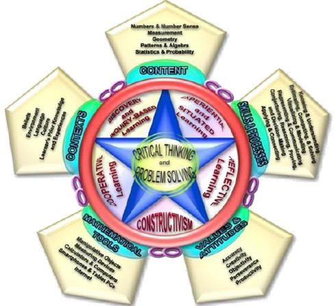

Figure 1. The Conceptual Framework of Mathematics Education

The Department of Education (2016a) explicitly presented that statistics and probability is taught from Kinder to Grade 10 except in Grade 9. At the end of every grade level from Kinder to Grade 8 and Grade 10, the learner demonstrates understanding and appreciation of key concepts, skills, and principles involving the following topics as grade level standards respectively: data collection and tables; tables, pictographs, and outcomes; same topics as for Grade 1; tables, bar graphs, and outcomes; tables, bar graphs and simple experiments; tables, line graphs, and experimental probability; tables, pie graphs, and experimental and theoretical probability; data collection and presentation, and measures of central tendency and variability; probability of simple events; combinatorics and probability, and measures of position. These key concepts, skills and principles are learned, understood and appreciated as applied – using appropriate technology – in problem solving, critical thinking, communicating, reasoning, making connections, representations, and decisions in real life (Department of Education, 2016a).

The Department of Education (2016a) also explicitly presented the teaching and learning of statistics and probability in Kinder until Grade 8 and Grade 10. In Kinder, there are 7 domains. Statistics and probability is one of the four sub-domains in the mathematics domain (Department of Education, 2016b). From Grade 1 to Grade 6, statistics and probability is taught in the 4th quarter together with the measurement strand. In Grade 5, learners will start using a scientific calculator. In Grade 7, the subject is taught in the entire 4th quarter. Starting Grade 7, teaching and learning the subject is aided by learning materials. However, the subject is taught in the 4th quarter together with the geometry strand in Grade 8. In Grade 10, the subject is covered in the 3rd and 4th quarter.

In the senior high school, there is a core statistics and probability course (Department of Education, 2013). It is offered in all academic tracts. The course is offered either in Grade 11 or Grade 12 depending on the academic tract of the learner. The curriculum guide stipulates that at the end of the course, the learners must know how to find the mean and variance of a random variable, to apply sampling techniques and distributions, to estimate population mean and proportion, to perform hypothesis testing on population mean and proportion, and to perform correlation and regression analyses on real-life problems. The course will cover random variables and probability distributions, normal distribution, test of hypothesis. Topics on correlation and regression analysis are included to enrich the course.

## Statistics Education in Australia

According to the Australian Curriculum Assessment and Reporting Authority (2015a), the Australian Curriculum: Mathematics is crafted in such a way that learning mathematics enriches the lives of and enables all Australians. The curriculum for the Foundation Year Level to Year 10 aims to ensure that students: are confident, creative users and communicators of mathematics, able to investigate, represent and interpret situations in their personal and work lives and as active citizens; develop an increasingly sophisticated understanding of mathematical concepts and fluency with processes, and are able to pose and solve problems and reason in number and algebra, measurement and geometry, and statistics and probability; recognize connections between the areas of mathematics and other disciplines and appreciate mathematics as an accessible and enjoyable discipline to study (Australian Curriculum Assessment and Reporting Authority, 2015a). The curriculum empowers and equips students with mathematics skills needed in their personal, work and civic life, and provides the fundamentals on which mathematical specialties and professional applications of mathematics are built.

In all the year levels, there are three content strands and four proficiency strands (Australian Curriculum Assessment and Reporting Authority, 2015a). The content strands are number and algebra, measurement and geometry, and statistics and probability. The proficiency strands are understanding, fluency, problem solving, and reasoning. This strand describes how content is explored or developed. The curriculum is organized around the interaction of the three content strands and the four proficiency strands. This structure ensures a meaningful basis for the development of concepts in the learning of mathematics and that the proficiency in mathematics skills develops through the years.

Statistics and probability develops initially in parallel with the other content strands through the proficiency strands and the curriculum then progressively builds, connects and relates them (Australian Curriculum Assessment and Reporting Authority, 2015a). Students recognize and analyse data and draw inferences. They represent, summarize and interpret data and undertake purposeful investigations involving the collection and interpretation of data. They assess likelihood and assign probabilities using experimental and theoretical approaches. They develop an increasingly sophisticated ability to critically evaluate chance and data concepts and make reasoned judgments and decisions, as well as building skills to critically evaluate statistical information and develop intuitions about data. There are two sub-strands in the statistics and probability strands; chance and data representation and interpretation. Chance is covered from Year 1 to Year 10 and data representation and interpretation from Foundation to Year 10 respectively.

It is explicit in the curriculum that statistics and probability is taught from Foundation to Year 10. The following are achievement standards in statistics and probability from Foundation to Year 10 respectively: students answer simple questions to collect information and make simple inferences; students classify outcomes of simple familiar events, describe data displays and collect data by asking questions, and draw simple data displays and make simple inferences; students describe outcomes for everyday events, make sense of collected information, and collect, organize and represent data to make simple inferences; students conduct chance experiments and list possible outcomes, interpret and compare data displays, and conduct simple data investigations for categorical variables; students identify dependent and independent events, list the probabilities of everyday events, describe different methods for data collection and representation, and evaluate their effectiveness, and construct data displays from given or collected data; students list outcomes of chance experiments with equally likely outcomes and assign probabilities between 0 and 1, interpret different data sets, and pose questions to gather data, and construct data displays appropriate for the data; students describe probabilities using simple fractions, decimals and percentages, compare observed and expected frequencies, interpret and compare a variety of data displays including those displays for two categorical variables, and interpret secondary data displayed in the media; students determine the sample space for simple experiments with equally likely outcomes and assign probabilities to those outcomes, identify issues involving the collection of continuous data, describe the relationship between the median and mean in data displays, calculate mean, mode, median, and range for data sets, and construct stem-and-leaf plots and dot-plots; Students model authentic situations with two-way tables and Venn diagrams, choose appropriate language to describe events and experiments, determine the probabilities of complementary events and calculate the sum of probabilities, and explain issues related to the collection of data and the effect of outliers on means and medians in that data; students calculate relative frequencies to estimate probabilities, list outcomes for two-step experiments and assign probabilities for those outcomes, compare techniques for collecting data from primary and secondary sources, make sense of the position of the mean and median in skewed, symmetric and bi-modal displays to describe and interpret data, and construct histograms and back-to-back stem-and-leaf plots; students list outcomes for multi-step chance experiments and assign probabilities for these experiments, compare data sets by referring to the shapes of the various data displays, describe bivariate data where the independent variable is time, describe statistical relationships between two continuous variables, evaluate statistical reports, and calculate quartiles and inter-quartile ranges (Australian Curriculum Assessment and Reporting Authority, 2015a).

In the senior secondary Australian curriculum, there are four mathematics subjects; essential mathematics, general mathematics, mathematical methods, specialist mathematics (Australian Curriculum Assessment and Reporting Authority, 2015b). Each subject has been organized into four units and the last two units are cognitively more challenging than the first two units. Essential mathematics focuses on using mathematics effectively, efficiently and critically to make informed decisions. General mathematics focuses on using the techniques of discrete mathematics to solve problems in contexts that include financial modelling, network analysis, route and project planning, decision making, and discrete growth and decay. Mathematical methods focuses on the development of the use of calculus and statistical analysis. Specialist mathematics contains topics in functions and calculus that build on and deepen the ideas presented in mathematical methods as well as demonstrate their application in many areas. Specialist mathematics is the only mathematics subject that has been designed to not be taken as a stand-alone subject. Specialist mathematics is taken combined with mathematical methods. Statistics and probability is present in each of these four subjects. In essential mathematics; graphs, data collection, and probability and relative frequencies. In general mathematics; univariate data analysis and the statistical investigation process, bivariate data analysis, and time series analysis. In mathematical methods; counting and probability, discrete random variable, continuous random variables and the normal distribution, and interval estimates for proportions. In specialist mathematics; combinatorics and statistical inference.

## Comparison of the Philippine and Australian Statistics Education Curriculum

Statistics education is richer in the Australian curriculum. Although the two curriculum almost have the same topics covered in the statistics and probability strand, the advantage of the Australian curriculum is that it has more dept and focus in the essentials of learning statistics. This is ensured by the four proficiency strands. Each topic clearly increases in dept when moving to the next proficiency strand and this is maintained all through out the Foundation to Year 10 and even in the senior secondary education. This scheme also serves as basis to ensures a meaningful development of concepts. Nonetheless, these proficiency strands also make sure that essentials in the topics are the focus of learning. Although the Philippine curriculum has performance standards and learning competency, these are poor basis for meaningful development of dept in topics covered compared to the proficiency strands of the Australian curriculum. At the same time, focus on essentials like understanding, fluency, problem-solving and reasoning is not clearly stated.

The Australian curriculum is very detailed and complete, making it very clear and easy to understand for those who will implement it. Compared to the Philippine curriculum where in not much is written about performance standards and learning competencies.

# References

Australian Curriculum Assessment and Reporting Authority. (2015a). Australian curriculum: Mathematics f-10 curriculum. Retrieved July 13, 2019, from https://www.australiancurriculum.edu.au/download?view=f10

Australian Curriculum Assessment and Reporting Authority. (2015b). Australian curriculum: Mathematics senior secondary curriculum. Retrieved July 13, 2019, from https://www.australiancurriculum.edu.au/download?view=ss

Department of Education. (2013). *K to 12 senior high school core curriculum – statistics and probability*. Pasig City, Philippines: Author.

Department of Education. (2016a). *K to 12 curriculum guide: Mathematics (Grade 1 to Grade 10)*. Pasig City, Philippines: Author.

Department of Education. (2016b). *Standards and competencies for five-year-old filipino children*. Pasig City, Philippines: Author.

Franklin, C., Kader, G., Mewborn, D. S., Moreno, J., Peck, R., Perry, M., & Scheaffer, R. (2007). *Guidelines for assessment and instruction in statistics education (GAISE) report: A pre-k-12 curriculum framework*. Alexandria, VA: American Statistical Association.

KPMG, & MOWAT. (2014). *Future state 2030: The global megatrends shaping governments*. KPMG International.

SEI-DOST, & MATHTED. (2011). *Framework for philippine mathematics teacher education*. Manila: Author.